# Medical Flower Price Report

Value Analysis for Reefer Madness

## Reefer Madness

4401 East 46th Ave Suite B  
Denver, Colorado

**Rating:** 4.7⭐ (149 reviews)

**Phone:** (303) 322-3404

**Menu:** [View Menu](https://weedmaps.com/dispensaries/reefer-madness)

## Executive Summary

Cheapest ounce-equivalent (28g)

$28.35/oz

MED - Generations Garden - Bubba Gum / O...

1g • $1.00

Typical price (per product, 28g norm)

$61/oz

IQR $41–$91

Low-price coverage (28g)

35% ≤ $60/oz

74% ≤ $90/oz

💰 Largest bulk savings

49%

MED - Boulder Built - Mr. Nast...

1g @ $198/oz → 28g @ $101/oz

Bottom line: Mixed value (25–49% of products ≤ $60/oz, 28g norm)

### Category medians & counts

Pre-Pack Specialty

$28/oz (median, 28g)

min $28 • 2 products

Shake/Popcorn/Trim

$41/oz (median, 28g)

min $28 • 16 products

Bulk Value

$61/oz (median, 28g)

min $51 • 39 products

### Price band coverage (per product)

≤ $60 (28g)

20 (35%)

$61–$90 (28g)

22 (39%)

$91–$120 (28g)

15 (26%)

$121–$200 (28g)

0 (0%)

>$200 (28g)

0 (0%)

**Full Price Bands — per product (28g-normalized, unlimited) Click to expand**

#### ≤ $60

[output not shown]

#### $61–$90

| Product | Category | Best Size | Best Price | Best $/Oz (28g) |
| --- | --- | --- | --- | --- |
| MED - Boulder Built - Champagne Showers / Yellow Tier Buds | Bulk Value | 28g | $60.00 | $60.67 |
| MED - Legacy Grown - Alley Oop / Yellow Tier Premium Buds | Bulk Value | 28g | $60.00 | $60.67 |
| MED - Legacy Grown - Astronaut Status / Yellow Tier | Bulk Value | 28g | $60.00 | $60.67 |
| MED - Legacy Grown - Chilled Cherries / Yellow Tier Premium Buds | Bulk Value | 28g | $60.00 | $60.67 |
| MED - Legacy Grown - Crosstada / Yellow Tier Premium Buds | Bulk Value | 28g | $60.00 | $60.67 |
| MED - Legacy Grown - Dante's Wrath / Yellow Tier | Bulk Value | 28g | $60.00 | $60.67 |
| MED - Legacy Grown - Forbidden Runtz / Yellow Tier Premium Buds | Bulk Value | 28g | $60.00 | $60.67 |
| MED - Legacy Grown - Gelato Cake / Yellow Tier | Bulk Value | 28g | $60.00 | $60.67 |
| MED - Legacy Grown - Gold Digger / Yellow Tier Premium Flower | Bulk Value | 28g | $60.00 | $60.67 |
| MED - Legacy Grown - Lemon Cherry Gelato / Yellow Tier Buds | Bulk Value | 28g | $60.00 | $60.67 |
| MED - Legacy Grown - MIA Runtz / Yellow Tier Buds | Bulk Value | 28g | $60.00 | $60.67 |
| MED - Legacy Grown - Mike Gary / Yellow Tier Buds | Bulk Value | 28g | $60.00 | $60.67 |
| MED - Legacy Grown - Nag Champa / Yellow Tier Buds | Bulk Value | 28g | $60.00 | $60.67 |
| MED - Legacy Grown - Point Break / Yellow Tier Buds | Bulk Value | 28g | $60.00 | $60.67 |
| MED - Legacy Grown - Pop Rockets / Yellow Tier Premium Buds | Bulk Value | 28g | $60.00 | $60.67 |
| MED - Legacy Grown - Satsuma Sherb / Yellow Tier Buds | Bulk Value | 28g | $60.00 | $60.67 |
| MED - Legacy Grown - Sherb Stack / Yellow Tier Premium Buds | Bulk Value | 28g | $60.00 | $60.67 |
| MED - Legacy Grown - Soap / Yellow Tier Premium Buds | Bulk Value | 28g | $60.00 | $60.67 |
| MED - Legacy Grown - Watermelon Rush / Yellow Tier \| Buds | Bulk Value | 28g | $60.00 | $60.67 |
| MED - Karmaceuticals - Jelly Pie / Green Tier \| Buds | Bulk Value | 28g | $70.00 | $70.88 |
| MED - Karmaceuticals - Oreoz / Green Tier \| Buds | Bulk Value | 28g | $70.00 | $70.88 |
| MED - Karmaceuticals - Punch Breath / Green Tier \| Buds | Bulk Value | 28g | $70.00 | $70.88 |

#### $91–$120

| Product | Category | Best Size | Best Price | Best $/Oz (28g) |
| --- | --- | --- | --- | --- |
| MED - Cherry - Bernscotti / Purple-Tier Buds | Bulk Value | 28g | $90.00 | $91.00 |
| MED - Cherry - Blockberry / Purple Tier Buds | Bulk Value | 28g | $90.00 | $91.00 |
| MED - Cherry - Lemonatti / Purple-Tier Buds | Bulk Value | 28g | $90.00 | $91.00 |
| MED - Cherry - Quicksand / Purple Tier Buds | Bulk Value | 28g | $90.00 | $91.00 |
| MED - Natty Rems - Banana Punch / Purple Tier \| Premium Buds | Bulk Value | 28g | $90.00 | $91.00 |
| MED - Natty Rems - Catalina Wine Mixer / Purple Tier \| Premium Buds | Bulk Value | 28g | $90.00 | $91.00 |
| MED - Natty Rems - Golden Goat / Purple Tier \| Premium Buds | Bulk Value | 28g | $90.00 | $91.00 |
| MED - Natty Rems - Grape Cream Cake / Purple Tier \| Premium Buds | Bulk Value | 28g | $90.00 | $91.00 |
| MED - Natty Rems - Super Boof / Purple Tier \| Premium Buds | Bulk Value | 28g | $90.00 | $91.00 |
| MED - Boulder Built - Jelly Pancakes / Pink Tier Buds | Bulk Value | 28g | $100.00 | $101.21 |
| MED - Boulder Built - Mr. Nasty / Pink Tier Buds | Bulk Value | 28g | $100.00 | $101.21 |
| MED - Boulder Built - Paris Hilton / Pink Tier Buds | Bulk Value | 28g | $100.00 | $101.21 |
| MED - Boulder Built - Peanut Butter Gelato / Pink Tier Buds | Bulk Value | 14g | $50.00 | $101.21 |
| MED - Petrol - Black Magic / Pink Tier Buds | Bulk Value | 28g | $100.00 | $101.21 |
| MED - Petrol - Sugar Rainbow Luxe / Pink Tier Buds | Bulk Value | 28g | $100.00 | $101.21 |

### Top 3 best-value products (by $/oz)

🥇

MED - Generations Garden - Bubba Gum / O...

Pre-Pack Specialty • 1g • $1.00

$28.35/oz

28g normalized

🥈

MED - Legacy Grown - Four Kings / "Seede...

Pre-Pack Specialty • 1g • $1.00

$28.35/oz

28g normalized

🥉

Bulk Value • 28g • $50.00

$50.75/oz

28g normalized

## Price Distribution Visuals

### Box Plot (quartiles + whiskers)

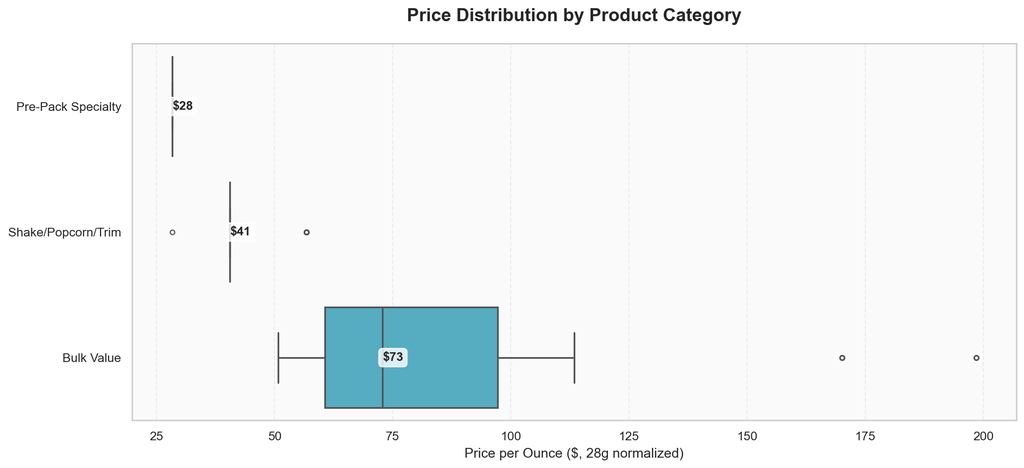

### ECDF Overlay (cumulative comparison)

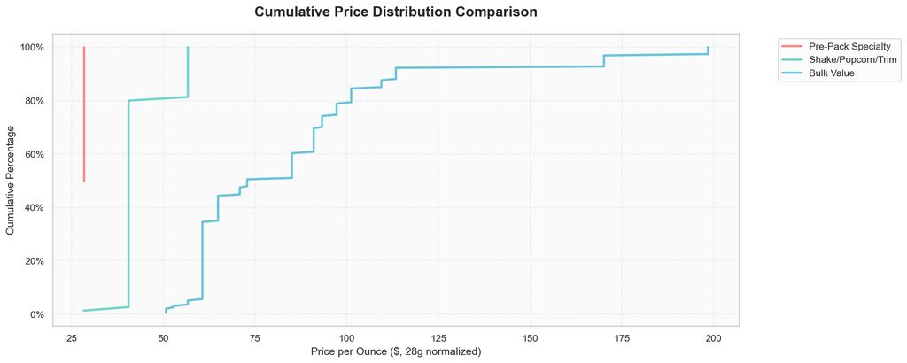

## 💎 Pre-Pack Specialty

| name | size_label | price | price_per_oz | Efficient Sizes | Max Savings vs Smallest |
| --- | --- | --- | --- | --- | --- |
| MED - Generations Garden - Bubba Gum / Orange-Tier Buds | 1g | $1.00 | $28.35 | 1g | NaN |
| MED - Legacy Grown - Four Kings / "Seeded" Tier Buds | 1g | $1.00 | $28.35 | 1g | NaN |

## 💸 Shake/Popcorn/Trim

| name | size_label | price | price_per_oz | Efficient Sizes | Max Savings vs Smallest |
| --- | --- | --- | --- | --- | --- |
| MED - Long Gone Farms - Mystery Machine / Red-Tier Popcorn (Copy) | 1g | $1.00 | $28.35 | 1g | NaN |
| MED - Boulder Built - Ca*dy Fumez / Red-Tier Popcorn | 14g | $20.00 | $40.54 | 1g → 3.5g | 29% |
| MED - Boulder Built - Habanero Peaches / Red-Tier Popcorn | 28g | $40.00 | $40.54 | 1g → 3.5g | 29% |
| MED - Boulder Built - Sudz (Soap x Devil Driver) / Red -Tier Popcorn | 28g | $40.00 | $40.54 | 1g → 3.5g | 29% |
| MED - Legacy Grown - Crosstada / Red tier Popcorn | 28g | $40.00 | $40.54 | 1g → 3.5g | 29% |
| MED - Legacy Grown - Point Break / Red tier Popcorn | 28g | $40.00 | $40.54 | 1g → 3.5g | 29% |
| MED - NuHi - Blue Dream / Red Tier \| Popcorn | 28g | $40.00 | $40.54 | 1g → 3.5g | 29% |
| MED - NuHi - Durban Poison / Red Tier \| Popcorn | 28g | $40.00 | $40.54 | 1g → 3.5g | 29% |
| MED - NuHi - Ecto-Cooler / Red Tier \| Popcorn | 28g | $40.00 | $40.54 | 1g → 3.5g | 29% |
| MED - NuHi - Grape Gas / Red Tier \| Popcorn | 28g | $40.00 | $40.54 | 1g → 3.5g | 29% |
| MED - NuHi - Lilac Diesel / Red Tier \| Popcorn | 28g | $40.00 | $40.54 | 1g → 3.5g | 29% |
| MED - NuHi - Pineapple Fields / Red Tier \| Popcorn | 28g | $40.00 | $40.54 | 1g → 3.5g | 29% |
| MED - Vera - A1 Stank Sauce x Furious George / Red tier Popcorn | 28g | $40.00 | $40.54 | 1g → 3.5g | 29% |
| MED - Vera - Jack Herer / Red tier Popcorn | 28g | $40.00 | $40.54 | 1g → 3.5g | 29% |
| MED - Vera - Sherblaster / Red tier Popcorn | 28g | $40.00 | $40.54 | 1g → 3.5g | 29% |
| MED - Vera - Speakeasy / Red tier Popcorn | 28g | $40.00 | $40.54 | 1g → 3.5g | 29% |

## 🏆 Bulk Value

| name | size_label | price | price_per_oz | Efficient Sizes | Max Savings vs Smallest |
| --- | --- | --- | --- | --- | --- |
| MED - Leiffa - MAC / Orange Tier Flower | 28g | $50.00 | $50.75 | 1g → 7g → 14g | 10% |
| MED - Leiffa - Motor Mouth / Orange Tier Flower | 28g | $50.00 | $50.75 | 1g → 7g → 14g | 10% |
| MED - Boulder Built - Champagne Showers / Yellow Tier Buds | 28g | $60.00 | $60.67 | 1g → 3.5g → 7g | 29% |
| MED - Legacy Grown - Alley Oop / Yellow Tier Premium Buds | 28g | $60.00 | $60.67 | 1g → 3.5g → 7g | 29% |
| MED - Legacy Grown - Astronaut Status / Yellow Tier | 28g | $60.00 | $60.67 | 1g → 3.5g → 7g | 29% |
| MED - Legacy Grown - Chilled Cherries / Yellow Tier Premium Buds | 28g | $60.00 | $60.67 | 1g → 3.5g → 7g | 29% |
| MED - Legacy Grown - Crosstada / Yellow Tier Premium Buds | 28g | $60.00 | $60.67 | 1g → 3.5g → 7g | 29% |
| MED - Legacy Grown - Dante's Wrath / Yellow Tier | 28g | $60.00 | $60.67 | 1g → 3.5g → 7g | 29% |
| MED - Legacy Grown - Forbidden Runtz / Yellow Tier Premium Buds | 28g | $60.00 | $60.67 | 1g → 3.5g → 7g | 29% |
| MED - Legacy Grown - Gelato Cake / Yellow Tier | 28g | $60.00 | $60.67 | 1g → 3.5g → 7g | 29% |
| MED - Legacy Grown - Gold Digger / Yellow Tier Premium Flower | 28g | $60.00 | $60.67 | 1g → 3.5g → 7g | 29% |
| MED - Legacy Grown - Lemon Cherry Gelato / Yellow Tier Buds | 28g | $60.00 | $60.67 | 1g → 3.5g → 7g | 29% |
| MED - Legacy Grown - MIA Runtz / Yellow Tier Buds | 28g | $60.00 | $60.67 | 1g → 3.5g → 7g | 29% |
| MED - Legacy Grown - Mike Gary / Yellow Tier Buds | 28g | $60.00 | $60.67 | 1g → 3.5g → 7g | 29% |
| MED - Legacy Grown - Nag Champa / Yellow Tier Buds | 28g | $60.00 | $60.67 | 1g → 3.5g → 7g | 29% |
| MED - Legacy Grown - Point Break / Yellow Tier Buds | 28g | $60.00 | $60.67 | 1g → 3.5g → 7g | 29% |
| MED - Legacy Grown - Pop Rockets / Yellow Tier Premium Buds | 28g | $60.00 | $60.67 | 1g → 3.5g → 7g | 29% |
| MED - Legacy Grown - Satsuma Sherb / Yellow Tier Buds | 28g | $60.00 | $60.67 | 1g → 3.5g → 7g | 29% |
| MED - Legacy Grown - Sherb Stack / Yellow Tier Premium Buds | 28g | $60.00 | $60.67 | 1g → 3.5g → 7g | 29% |
| MED - Legacy Grown - Soap / Yellow Tier Premium Buds | 28g | $60.00 | $60.67 | 1g → 3.5g → 7g | 29% |

## Bulk Savings Spotlight — Full Detail

| Product | Category | Small Size | Small (g) | Small Price | Small $/oz (28g) | Large Size | Large (g) | Large Price | Large $/oz (28g) | Savings % | Δ $/oz (28g) |
| --- | --- | --- | --- | --- | --- | --- | --- | --- | --- | --- | --- |
| MED - Boulder Built - Mr. Nasty / Pink Tier Buds | Bulk Value | 1g | 1g | $7.00 | $198.45 | 28g | 28.35g | $100.00 | $101.21 | 49% | $97.24 |
| MED - Boulder Built - Jelly Pancakes / Pink Tier Buds | Bulk Value | 1g | 1g | $7.00 | $198.45 | 28g | 28.35g | $100.00 | $101.21 | 49% | $97.24 |
| MED - Boulder Built - Paris Hilton / Pink Tier Buds | Bulk Value | 1g | 1g | $7.00 | $198.45 | 28g | 28.35g | $100.00 | $101.21 | 49% | $97.24 |
| MED - Boulder Built - Peanut Butter Gelato / Pink Tier Buds | Bulk Value | 1g | 1g | $7.00 | $198.45 | 14g | 14.175g | $50.00 | $101.21 | 49% | $97.24 |
| MED - Petrol - Black Magic / Pink Tier Buds | Bulk Value | 1g | 1g | $7.00 | $198.45 | 28g | 28.35g | $100.00 | $101.21 | 49% | $97.24 |
| MED - Petrol - Sugar Rainbow Luxe / Pink Tier Buds | Bulk Value | 1g | 1g | $7.00 | $198.45 | 28g | 28.35g | $100.00 | $101.21 | 49% | $97.24 |
| MED - Cherry - Quicksand / Purple Tier Buds | Bulk Value | 1g | 1g | $6.00 | $170.10 | 28g | 28.35g | $90.00 | $91.00 | 47% | $79.10 |
| MED - Cherry - Lemonatti / Purple-Tier Buds | Bulk Value | 1g | 1g | $6.00 | $170.10 | 28g | 28.35g | $90.00 | $91.00 | 47% | $79.10 |
| MED - Natty Rems - Grape Cream Cake / Purple Tier \| Premium Buds | Bulk Value | 1g | 1g | $6.00 | $170.10 | 28g | 28.35g | $90.00 | $91.00 | 47% | $79.10 |
| MED - Natty Rems - Golden Goat / Purple Tier \| Premium Buds | Bulk Value | 1g | 1g | $6.00 | $170.10 | 28g | 28.35g | $90.00 | $91.00 | 47% | $79.10 |
| MED - Natty Rems - Catalina Wine Mixer / Purple Tier \| Premium Buds | Bulk Value | 1g | 1g | $6.00 | $170.10 | 28g | 28.35g | $90.00 | $91.00 | 47% | $79.10 |
| MED - Natty Rems - Banana Punch / Purple Tier \| Premium Buds | Bulk Value | 1g | 1g | $6.00 | $170.10 | 28g | 28.35g | $90.00 | $91.00 | 47% | $79.10 |
| MED - Cherry - Bernscotti / Purple-Tier Buds | Bulk Value | 1g | 1g | $6.00 | $170.10 | 28g | 28.35g | $90.00 | $91.00 | 47% | $79.10 |
| MED - Cherry - Blockberry / Purple Tier Buds | Bulk Value | 1g | 1g | $6.00 | $170.10 | 28g | 28.35g | $90.00 | $91.00 | 47% | $79.10 |
| MED - Natty Rems - Super Boof / Purple Tier \| Premium Buds | Bulk Value | 1g | 1g | $6.00 | $170.10 | 28g | 28.35g | $90.00 | $91.00 | 47% | $79.10 |
| MED - Karmaceuticals - Punch Breath / Green Tier \| Buds | Bulk Value | 1g | 1g | $4.00 | $113.40 | 28g | 28.35g | $70.00 | $70.88 | 38% | $42.53 |
| MED - Karmaceuticals - Oreoz / Green Tier \| Buds | Bulk Value | 1g | 1g | $4.00 | $113.40 | 28g | 28.35g | $70.00 | $70.88 | 38% | $42.53 |
| MED - Karmaceuticals - Jelly Pie / Green Tier \| Buds | Bulk Value | 1g | 1g | $4.00 | $113.40 | 28g | 28.35g | $70.00 | $70.88 | 38% | $42.53 |
| MED - Legacy Grown - Forbidden Runtz / Yellow Tier Premium Buds | Bulk Value | 1g | 1g | $3.00 | $85.05 | 28g | 28.35g | $60.00 | $60.67 | 29% | $24.38 |
| MED - Legacy Grown - Crosstada / Yellow Tier Premium Buds | Bulk Value | 1g | 1g | $3.00 | $85.05 | 28g | 28.35g | $60.00 | $60.67 | 29% | $24.38 |
| MED - Boulder Built - Champagne Showers / Yellow Tier Buds | Bulk Value | 1g | 1g | $3.00 | $85.05 | 28g | 28.35g | $60.00 | $60.67 | 29% | $24.38 |
| MED - Legacy Grown - Alley Oop / Yellow Tier Premium Buds | Bulk Value | 1g | 1g | $3.00 | $85.05 | 28g | 28.35g | $60.00 | $60.67 | 29% | $24.38 |
| MED - Legacy Grown - Satsuma Sherb / Yellow Tier Buds | Bulk Value | 1g | 1g | $3.00 | $85.05 | 28g | 28.35g | $60.00 | $60.67 | 29% | $24.38 |
| MED - Legacy Grown - Sherb Stack / Yellow Tier Premium Buds | Bulk Value | 1g | 1g | $3.00 | $85.05 | 28g | 28.35g | $60.00 | $60.67 | 29% | $24.38 |
| MED - Legacy Grown - Watermelon Rush / Yellow Tier \| Buds | Bulk Value | 1g | 1g | $3.00 | $85.05 | 28g | 28.35g | $60.00 | $60.67 | 29% | $24.38 |
| MED - Legacy Grown - Gold Digger / Yellow Tier Premium Flower | Bulk Value | 1g | 1g | $3.00 | $85.05 | 28g | 28.35g | $60.00 | $60.67 | 29% | $24.38 |
| MED - Legacy Grown - Chilled Cherries / Yellow Tier Premium Buds | Bulk Value | 1g | 1g | $3.00 | $85.05 | 28g | 28.35g | $60.00 | $60.67 | 29% | $24.38 |
| MED - Legacy Grown - Astronaut Status / Yellow Tier | Bulk Value | 1g | 1g | $3.00 | $85.05 | 28g | 28.35g | $60.00 | $60.67 | 29% | $24.38 |
| MED - Legacy Grown - Dante's Wrath / Yellow Tier | Bulk Value | 1g | 1g | $3.00 | $85.05 | 28g | 28.35g | $60.00 | $60.67 | 29% | $24.38 |
| MED - Legacy Grown - Gelato Cake / Yellow Tier | Bulk Value | 1g | 1g | $3.00 | $85.05 | 28g | 28.35g | $60.00 | $60.67 | 29% | $24.38 |
| MED - Legacy Grown - Soap / Yellow Tier Premium Buds | Bulk Value | 1g | 1g | $3.00 | $85.05 | 28g | 28.35g | $60.00 | $60.67 | 29% | $24.38 |
| MED - Legacy Grown - Pop Rockets / Yellow Tier Premium Buds | Bulk Value | 1g | 1g | $3.00 | $85.05 | 28g | 28.35g | $60.00 | $60.67 | 29% | $24.38 |
| MED - Legacy Grown - Lemon Cherry Gelato / Yellow Tier Buds | Bulk Value | 1g | 1g | $3.00 | $85.05 | 28g | 28.35g | $60.00 | $60.67 | 29% | $24.38 |
| MED - Legacy Grown - MIA Runtz / Yellow Tier Buds | Bulk Value | 1g | 1g | $3.00 | $85.05 | 28g | 28.35g | $60.00 | $60.67 | 29% | $24.38 |
| MED - Legacy Grown - Mike Gary / Yellow Tier Buds | Bulk Value | 1g | 1g | $3.00 | $85.05 | 28g | 28.35g | $60.00 | $60.67 | 29% | $24.38 |
| MED - Legacy Grown - Nag Champa / Yellow Tier Buds | Bulk Value | 1g | 1g | $3.00 | $85.05 | 28g | 28.35g | $60.00 | $60.67 | 29% | $24.38 |
| MED - Legacy Grown - Point Break / Yellow Tier Buds | Bulk Value | 1g | 1g | $3.00 | $85.05 | 28g | 28.35g | $60.00 | $60.67 | 29% | $24.38 |
| MED - Boulder Built - Habanero Peaches / Red-Tier Popcorn | Shake/Popcorn/Trim | 1g | 1g | $2.00 | $56.70 | 28g | 28.35g | $40.00 | $40.54 | 29% | $16.16 |
| MED - Legacy Grown - Crosstada / Red tier Popcorn | Shake/Popcorn/Trim | 1g | 1g | $2.00 | $56.70 | 28g | 28.35g | $40.00 | $40.54 | 29% | $16.16 |
| MED - Boulder Built - Sudz (Soap x Devil Driver) / Red -Tier Popcorn | Shake/Popcorn/Trim | 1g | 1g | $2.00 | $56.70 | 28g | 28.35g | $40.00 | $40.54 | 29% | $16.16 |
| MED - Boulder Built - Ca*dy Fumez / Red-Tier Popcorn | Shake/Popcorn/Trim | 1g | 1g | $2.00 | $56.70 | 14g | 14.175g | $20.00 | $40.54 | 29% | $16.16 |
| MED - Legacy Grown - Point Break / Red tier Popcorn | Shake/Popcorn/Trim | 1g | 1g | $2.00 | $56.70 | 28g | 28.35g | $40.00 | $40.54 | 29% | $16.16 |
| MED - NuHi - Grape Gas / Red Tier \| Popcorn | Shake/Popcorn/Trim | 1g | 1g | $2.00 | $56.70 | 28g | 28.35g | $40.00 | $40.54 | 29% | $16.16 |
| MED - NuHi - Ecto-Cooler / Red Tier \| Popcorn | Shake/Popcorn/Trim | 1g | 1g | $2.00 | $56.70 | 28g | 28.35g | $40.00 | $40.54 | 29% | $16.16 |
| MED - NuHi - Blue Dream / Red Tier \| Popcorn | Shake/Popcorn/Trim | 1g | 1g | $2.00 | $56.70 | 28g | 28.35g | $40.00 | $40.54 | 29% | $16.16 |
| MED - NuHi - Durban Poison / Red Tier \| Popcorn | Shake/Popcorn/Trim | 1g | 1g | $2.00 | $56.70 | 28g | 28.35g | $40.00 | $40.54 | 29% | $16.16 |
| MED - Vera - A1 Stank Sauce x Furious George / Red tier Popcorn | Shake/Popcorn/Trim | 1g | 1g | $2.00 | $56.70 | 28g | 28.35g | $40.00 | $40.54 | 29% | $16.16 |
| MED - Vera - Jack Herer / Red tier Popcorn | Shake/Popcorn/Trim | 1g | 1g | $2.00 | $56.70 | 28g | 28.35g | $40.00 | $40.54 | 29% | $16.16 |
| MED - NuHi - Pineapple Fields / Red Tier \| Popcorn | Shake/Popcorn/Trim | 1g | 1g | $2.00 | $56.70 | 28g | 28.35g | $40.00 | $40.54 | 29% | $16.16 |
| MED - NuHi - Lilac Diesel / Red Tier \| Popcorn | Shake/Popcorn/Trim | 1g | 1g | $2.00 | $56.70 | 28g | 28.35g | $40.00 | $40.54 | 29% | $16.16 |
| MED - Vera - Sherblaster / Red tier Popcorn | Shake/Popcorn/Trim | 1g | 1g | $2.00 | $56.70 | 28g | 28.35g | $40.00 | $40.54 | 29% | $16.16 |
| MED - Vera - Speakeasy / Red tier Popcorn | Shake/Popcorn/Trim | 1g | 1g | $2.00 | $56.70 | 28g | 28.35g | $40.00 | $40.54 | 29% | $16.16 |
| MED - Leiffa - Motor Mouth / Orange Tier Flower | Bulk Value | 1g | 1g | $2.00 | $56.70 | 28g | 28.35g | $50.00 | $50.75 | 10% | $5.95 |
| MED - Leiffa - MAC / Orange Tier Flower | Bulk Value | 1g | 1g | $2.00 | $56.70 | 28g | 28.35g | $50.00 | $50.75 | 10% | $5.95 |